# Board Game Geek Review Predictor

## By: Ankit Khanna

### Id: 1001553616

```python
from collections import Counter
from nltk.corpus import stopwords
from wordcloud import WordCloud
from sklearn.model_selection import train_test_split, cross_val_score
from sklearn.naive_bayes import MultinomialNB
from sklearn.neighbors import KNeighborsClassifier
from sklearn import svm
from sklearn.model_selection import cross_val_score
from sklearn.feature_extraction.text import CountVectorizer
from sklearn import metrics
from sklearn.metrics import confusion_matrix

import pandas as pd
import numpy as np
import random
import string
import matplotlib.pyplot as plt
import seaborn as sns

# for suppressing warnings
import warnings
warnings.filterwarnings("ignore")
```

### Reading the Dataset

Reading the whole dataset and process of pre-processing was too much for computation, so taking a subset of the dataset

```python
# bgg_reviews = pd.read_csv("/kaggle/input/boardgamegeek-reviews/bgg-13m-reviews.csv")
bgg_reviews = pd.read_csv("BoardGameGeekReviews/bgg-15m-reviews.csv",
                          skiprows=lambda i: i>0 and random.random() > 0.01, index_col=0)
bgg_reviews.head()
```

|  | user | rating | comment | ID | name |
| --- | --- | --- | --- | --- | --- |
| 97 | mikka | 10.0 | NaN | 30549 | Pandemic |
| 127 | Narayannis | 10.0 | An excellent game, betrayed by the endless (an... | 822 | Carcassonne |
| 187 | JamillDoghair | 10.0 | NaN | 822 | Carcassonne |
| 207 | hreimer | 10.0 | i will never tire of this game.. Awesome | 13 | Catan |
| 235 | pbowen | 10.0 | Everyone that I've introduced this game to has... | 13 | Catan |

### Finding missing/NaN values and Dropping redundant rows and columns

```python
bgg_reviews.dropna(how='any', subset=['comment'], inplace=True)
bgg_reviews.drop(['user', 'ID', 'name'], axis=1, inplace=True)
bgg_reviews.head()
```

|  | rating | comment |
| --- | --- | --- |
| 127 | 10.0 | An excellent game, betrayed by the endless (an... |
| 207 | 10.0 | i will never tire of this game.. Awesome |
| 235 | 10.0 | Everyone that I've introduced this game to has... |
| 308 | 10.0 | Amped up Fairy Tale. Some cards are worth poi... |
| 669 | 10.0 | Simple concept but makes you think and unleash... |

### Pre-processing Data

1. Lower-Casing all text
2. Removing Punctuation
3. Removing Stopwords

```python
# lowercasing and removing punctuation
bgg_reviews['cleaned'] = bgg_reviews['comment'].str.lower().apply(lambda x:''.join([i for i in x if i not in string.punctuation]))

# stopwords
stopwords = stopwords.words('english')
stopwords.extend(('game','play','played','players','player','people','really','board','games','one','plays','cards','would'))
stopwords[-10:]

# removing stopwords
bgg_reviews['cleaned'] = bgg_reviews['cleaned'].apply(lambda x: ' '.join([word for word in x.split() if word not in (stopwords)]))
bgg_reviews.head()
```

|  | rating | comment | cleaned |
| --- | --- | --- | --- |
| 127 | 10.0 | An excellent game, betrayed by the endless (an... | excellent betrayed endless sometimes meaningle... |
| 207 | 10.0 | i will never tire of this game.. Awesome | never tire awesome |
| 235 | 10.0 | Everyone that I've introduced this game to has... | everyone ive introduced liked friends family e... |
| 308 | 10.0 | Amped up Fairy Tale. Some cards are worth poi... | amped fairy tale worth points others give reso... |
| 669 | 10.0 | Simple concept but makes you think and unleash... | simple concept makes think unleashes creativit... |

### Top 10 most common words post Pre-processing

```python
Counter(" ".join(bgg_reviews["cleaned"]).split()).most_common(10)[:10]
```

```
[('like', 5753),
 ('fun', 5731),
 ('good', 4467),
 ('great', 3725),
 ('much', 3218),
 ('get', 3026),
 ('time', 2942),
 ('rules', 2362),
 ('playing', 2304),
 ('card', 2243)]
```

### Plotting Ratings vs respective Count

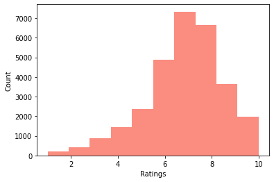

```python
n, bins, patches = plt.hist(bgg_reviews.rating, facecolor='salmon', alpha=0.9)

plt.xlabel('Ratings')
plt.ylabel('Count')
plt.show()
```

It can be observed that the data is UNBALANCED as the counts vary for each rating with 7 having the most count

### Visualisation of Top 100 most common words

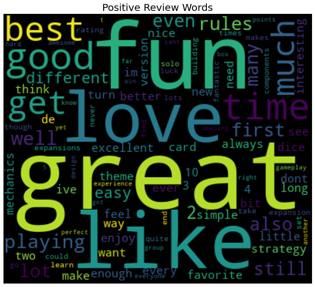

```python
# taking a positive review word as per rating > 8
pos_review_word = bgg_reviews.loc[bgg_reviews['rating'] > 8]

words = Counter([w for w in " ".join(pos_review_word['cleaned']).split()])
wc = WordCloud(width=400, height=350).generate_from_frequencies(dict(words.most_common(100)))
plt.figure(figsize=(15,10))
plt.imshow(wc, interpolation='bilinear')
plt.title('Positive Review Words', fontsize=20)
plt.axis('off');
plt.show()
```

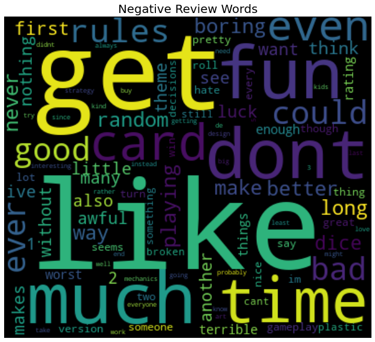

```python
# taking a negative review word as per rating < 3
neg_review_word = bgg_reviews.loc[bgg_reviews['rating'] < 3]

words = Counter([w for w in " ".join(neg_review_word['cleaned']).split()])
wc = WordCloud(width=400, height=350).generate_from_frequencies(dict(words.most_common(100)))
plt.figure(figsize=(15,10))
plt.imshow(wc, interpolation='bilinear')
plt.title('Negative Review Words', fontsize=20)
plt.axis('off');
plt.show()
```

From the above WordCloud the effect of the dataset being UNBALANCED can be observed as the Neg Review WordCloud contain postivie words as well

### Splitting the Dataset into 80/20 Train/Test

Using CountVectorizer as it breaks up the text into a matrix with each word (called "token" in NLP) being the column of the matrix and the value being the count of occurences Also, for easier computation rounding-off the ratings

```python
bgg_reviews_train, bgg_reviews_test = train_test_split(bgg_reviews, test_size=0.2, random_state=40)
count_vectorizer = CountVectorizer()

train_review = count_vectorizer.fit_transform(bgg_reviews_train['comment'])
train_tag = [round(r) for r in bgg_reviews_train['rating']]
test_review = count_vectorizer.transform(bgg_reviews_test['comment'])
test_tag = [round(r) for r in bgg_reviews_test['rating']]
```

### Trying different Classifiers

#### Multinomial Naive Bayes

Using this classifier as we have multiple classes to generalize the reviews

```python
mnb = MultinomialNB(alpha=1)
mnb.fit(train_review, train_tag)

score = mnb.score(test_review, test_tag)
print("Score for Multinomial Naive Bayes:", score)
```

```
Score for Multinomial Naive Bayes: 0.285546218487395
```

#### Support Vector Machine

Using SVM as it uses a subset of training points in the decision function (called support vectors), which makes it also memory efficient

```python
support_vector = svm.SVC()
support_vector.fit(train_review, train_tag)

score = support_vector.score(test_review, test_tag)
print("Score for Support Vector Machine:", score)
```

```
Score for Support Vector Machine: 0.2852100840336134
```

#### K-Nearest Neighbour

```python
knn = KNeighborsClassifier(n_neighbors=5)
knn.fit(train_review, train_tag)

score = knn.score(test_review, test_tag)
print("Score for K-Nearest Neighbour:", score)
```

```
Score for K-Nearest Neighbour: 0.20504201680672268
```

#### Multinomial Naive Bayes provides us with the best score with SVM being a very close second

For now, we will move forward with MNB and work towards Hyperparameter Tuning using Cross-Validation

```python
alpha_arr = list(np.arange(1,30,5))
scores_arr=[]

for a in alpha_arr:
    nb = MultinomialNB(alpha=a)
    cv_scores = cross_val_score(nb, train_review, train_tag, cv=5, scoring='accuracy')
    scores_arr.append(cv_scores.mean())
    print("Alpha value and respective score:", a, cv_scores.mean())
```

```
Alpha value and respective score: 1 0.28513184218844084
Alpha value and respective score: 6 0.26218699288919184
Alpha value and respective score: 11 0.25743817552236276
Alpha value and respective score: 16 0.25575721189925854
Alpha value and respective score: 21 0.2545385037814243
Alpha value and respective score: 26 0.2535299679863541
```

It can be observed that Score is maximum when alpha equals 1, the score for which we have already computed

#### Visualising Predictions via Confusion Matrix

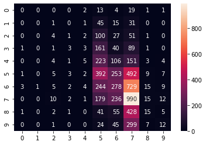

```python
predictions = mnb.predict(test_review)
cmatrix = confusion_matrix(test_tag, predictions)

sns.heatmap(cmatrix, annot=True, fmt='d')
```

### Testing Reviews

```python
test_review = "Best game ever"
print("Rating for the Review:", mnb.predict(count_vectorizer.transform([test_review])))
print("Prediction Probability:\n", mnb.predict_proba(count_vectorizer.transform([test_review])))
```

```
Rating for the Review: [10]
Prediction Probability:
 [[1.08799952e-04 7.57961628e-04 3.54353533e-03 1.18677685e-02
  1.76601095e-02 1.15608046e-01 1.79403943e-01 2.38784234e-01
  1.83371706e-01 2.48893895e-01]]
```

```python
test_review2 = "Good game"
print("Rating for the Review:", mnb.predict(count_vectorizer.transform([test_review2])))
print("Prediction Probability:\n", mnb.predict_proba(count_vectorizer.transform([test_review2])))
```

```
Rating for the Review: [7]
Prediction Probability:
 [[7.29040993e-05 9.42296273e-04 4.26758687e-03 1.70025348e-02
  4.25164686e-02 2.21446428e-01 3.10538490e-01 3.05426123e-01
  7.24182495e-02 2.53689189e-02]]
```

### Challenges faced:

1. Due to large dataset, execution time was too much. A random subset of the dataset for hence used.
2. The dataset contained many missing values. All of them were removed which improved accuracy.
3. Tried algorithms to classify the reviews, but with unbalanced data the results were somewhat biased.
4. Accuracy was too low because of many classes to predict from. For ex. "Good game" review can have a rating anywhere from 7 to 10.

### References:

1. Official scikit learn documentation: https://scikit-learn.org/
2. Dataset: https://www.kaggle.com/jvanelteren/boardgamegeek-reviews
3. Pickling models: https://machinelearningmastery.com/save-load-machine-learning-models-python-scikit-learn/
4. Hyperparameter Tuning: https://towardsdatascience.com/tuning-parameters-heres-how-39a4d1956f79
5. Preprocessing data: https://www.analyticsvidhya.com/blog/2019/08/how-to-remove-stopwords-text-normalization-nltk-spacy-gensim-python/
6. Existing Work: https://www.kaggle.com/jvanelteren/exploring-the-13m-reviews-bgg-dataset
7. Confusion Matrix and Heatmap: https://medium.com/@dtuk81/confusion-matrix-visualization-fc31e3f30fea